# Animal movement with

## 2.1 Reading telemetry data into **R**

We load a file into **R**, by telling it which file to load (`zoatrack_data.csv`) and where to find it (i.e. in the `Data` folder).

```r
# Load the cassowary data
cassdat <- read.csv('Data/zoatrack-data.csv', header = TRUE)
```

**A note about Excel files**

Donât use ‘.xlsx’ or ‘.xls’ files for saving data. The problem with ‘.xls’ and ‘.xlsx’ files are that they store extra info with the data that makes files larger than necessary and Excel formats can also unwittingly alter your data!

A stable way to save your data is as a ‘.csv’ file, which stands for ‘comma separated values’. These are simply values separated by ‘commas’ and rows defined by ‘returns’. If you select ‘Save asâ in excel, you can choose’.csv’ as one of the options. If you open the .csv file I have given you using a text editor, you will see it is just words, numbers and commas.

## 2.2 Accessing variables in the data frame

The rules we learned above for accessing values of an object also apply to data frames. A data frame is a special âclassâ of an object, where there are multiple variables, stored in names columns and multiple rows for our samples. Every variable has the same number of samples. A key difference from the objects we created earlier is that now we have both rows and columns. Rows and columns are indexed by using a comma as a separator. Try the following code:

```r
cassdat[1,] # Provides the first row of data
cassdat[1,3] # Provides the cell value from the 1st row and 3rd column
cassdat[,3]  # Provides the first column of data
cassdat[c(1,3),] # Provides the first and third date in the data frame
```

We can also access objects in a data frame by their names:

```r
cassdat$DATE #provides all the data for that object
cassdat$DATE[1:5] #provides athe first five values for that object
cassdat[,'DELETED'] #provides all the data for that object
```

We can get have a quick look at the data frame by typing:

```r
head(cassdat) #first 6 rows by default
tail(cassdat, 10) #last ten rows
```

This functionality is particularly useful if the data frame is very large!

Note the `()` around the data frame, as opposed to the `[]` we used for indexing. The `()` signify a *function*.

We can look at the data more closely using the `nrow`, `ncol`, `length`, `unique`, `str()` and `summary()` functions.

```r
nrow(cassdat) # number of rows in the data frame
ncol(cassdat) # number of columns in the data frame

length(cassdat$ANIMALID) # the number of values within a vector (same as the number of rows in the dataset)

unique(cassdat$ANIMALID) # We use the unique function to extract the unique values for the tags deployed

str(cassdat) # provides internal structure of an R object
summary(cassdat) # Provides result summary of the data frame
```

The `str()` function tell us how **R** has classified our objects into various data types.

In the result `summary()` of the dataframe, you can see what influence the *data type* has on the results that are presented. Those data columns that are are non-numeric and are not logicals (i.e. TRUE/FALSE) have been converted to factors (e.g. `ANIMALID` and `DATE`). For these factors, we are presented with a *frequency of occurences* for each factor level (note Annabelle has 1013 records). For those data columns that are numeric, we are presented with the minimum, mean, maximum and quartiles in the result summary.

## 2.3 Working with dates and times in **R**

See how **R** currently believes that our `DATE` column is a factorial? If we would like to plot our data in chronological order, or to extract the first or last locations for each animal, we first need to tell **R** that this `DATE` column represents actual dates.

To do this, we use the `as.POSIXct()` command, and state what datetime format our data is in using the `format = "%"` statement. Note that in this case we have the R default format of dates plus times: “Y-m-d H:M:S”.

We then do some statistical summaries to make sure this is correct using the `min`, `max` and `summary` command in **R**.

```r
cassdat$DATE <- as.POSIXct(cassdat$DATE, format = "%Y-%m-%d %H:%M:%S")

min(cassdat$DATE) # First location in our dataset
max(cassdat$DATE) # Last location in our dataset
summary(cassdat$DATE)
```

## 2.4 Filtering datasets

The `subset( )` function is one of the easiest way to select variables and observations.

In the following example, we subset our data for only those locations that have not been removed in ZoaTrack (`DELETED == FALSE`)

```r
# using subset function
cassdat2 <- subset(cassdat, DELETED== "FALSE")
```

By plotting these data, we can see which data points hace been removed

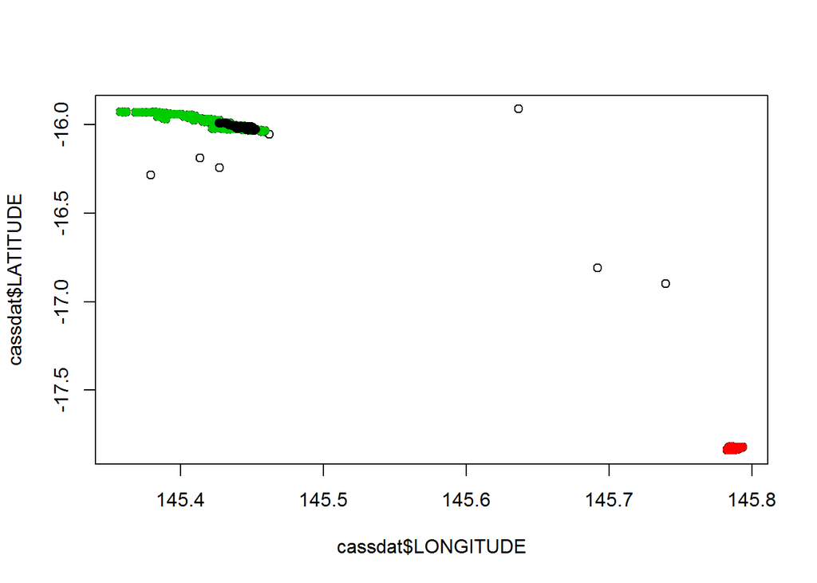

```r
plot(cassdat$LONGITUDE,cassdat$LATITUDE)
points(cassdat2$LONGITUDE,cassdat2$LATITUDE,col=cassdat$ANIMALID,pch=16)
```

From the interactive map at the beginning of this exercise, you will see that the deleted locations (white circles) were obatined prior to the devices being attached to the animals (i.e. at our accomodation in Cairns and enroute to our release site!)

However, this plot is a little misleading - the longitude and latitude fields have been distorted to fit on the x and y axes. In order to fix this, we’ll need to install a few additional R packages.

## 2.5 Packages

Part of the reason R has become so popular is the vast array of packages that are freely available and highly accessible. In the last few years, the number of packages has grown exponentially - 8000 at my last check on CRAN! These can help you to do a galaxy of different things in R, including running complex analyses, drawing beautiful figures, running R as a GIS, constructing your own R packages, building web pages and even writing introductory R course handbooks!

Once we have installed all our required packages using the `install.packages()` function, we then load the required packages using the `library()` function.

```r
library(sp)
library(rgdal)
library(rgeos)
library(adehabitatLT)
library(adehabitatHR)
```

Here we have installed and loaded our required **R** spatial packages, including the excellent adehabitatHR and adehabitatLS packages. These last two were built specifically for working with animal telemetry data.

[figure not shown]

Cassowary tracks overlayed with the animal’s home range

## 2.6 Working with spatial objects

R offers a variety of functions for importing, manipulating, analyzing, and exporting spatial data. Although one might at first consider this to be the exclusive domain of GIS software, using R can frequently provide a much more lightweight, yet equally effective solution that embeds within a larger analytic workflow.

One of the tricky aspects of pulling spatial data into your analytic workflow is that there are numerous complicated data formats. In fact, even within R itself, functions from different user-contributed packages often require the data to be structured in very different ways. The good news is that efforts are underway to standardize spatial data classes in R. This movement is facilitated by sp, an important base package for spatial operations in R. It provides definitions for basic spatial classes (points, lines, polygons, pixels, and grids) in an attempt to unify the way R packages represent and manage these sorts of data. It also includes some core functions for creating and manipulating these data structures. The hope is that all spatial R packages will use (or at least provide conversions to) the ‘Spatial’ data class and it’s derivatives, as now defined in the sp package. All else being equal, we favor R functions and packages that conform to the sp standard, as these are likely to provide the greatest future utility and durability.

[This website](http://www.maths.lancs.ac.uk/~rowlings/Teaching/UseR2012/cheatsheet.html) has a very useful style guide for working with `Spatial` objects.

## 2.7 `SpatialPoints` and animal locations

The most basic spatial data object is a point, which may have 2 (X, Y) or 3 components (X, Y, Z). A single coordinate, or a collection of coordinates, may be used to define a `SpatialPoints` object.

In this exercise we are going to convert our cassowary locations from a standard data frame object into a `SpatialPointsDataFrame` object.

```r
# First make a duplicate of points.df to retain the non-spatial version
cassdat.sp <- cassdat2

# Now convert the data.frame object into a SpatialPoints object
coordinates(cassdat.sp)<- c("LONGITUDE", "LATITUDE")
```

You can have a look at the created object using the `class` and `str` functions

```r
class(cassdat.sp)
str(cassdat.sp)
```

Notice the class has now become a `SpatialPointsDataFrame`. The `str()` output contains lots of `@` symbols which denote a different slot in this S4 R object. Typing `points.sp@data` will extract the attribute data (similar to the attribute table in ArcGIS). The X and Y locational information can now be found in the `@coords` slot. In addition `@bbox` contains the bounding box coordinates and the `@pro4string` contains the projection, or coordinate reference system (CRS) information.

```r
cassdat.sp@coords
cassdat.sp@proj4string
cassdat.sp@bbox
head(cassdat.sp@data)

# alternatively use the slot command to extract different
# packages of data. As the data is stored in the data slot
slot(cassdat.sp,'data')
```

Now let’s draw a simple spatial plot of the cassowary locations

```r
# First extract the names of cassowaries to help colour our plots
myids <- cassdat.sp@data[,1]
unique(myids)
```

```
## [1] M2        Annabelle Dooley
## Levels: Annabelle Dooley M2
```

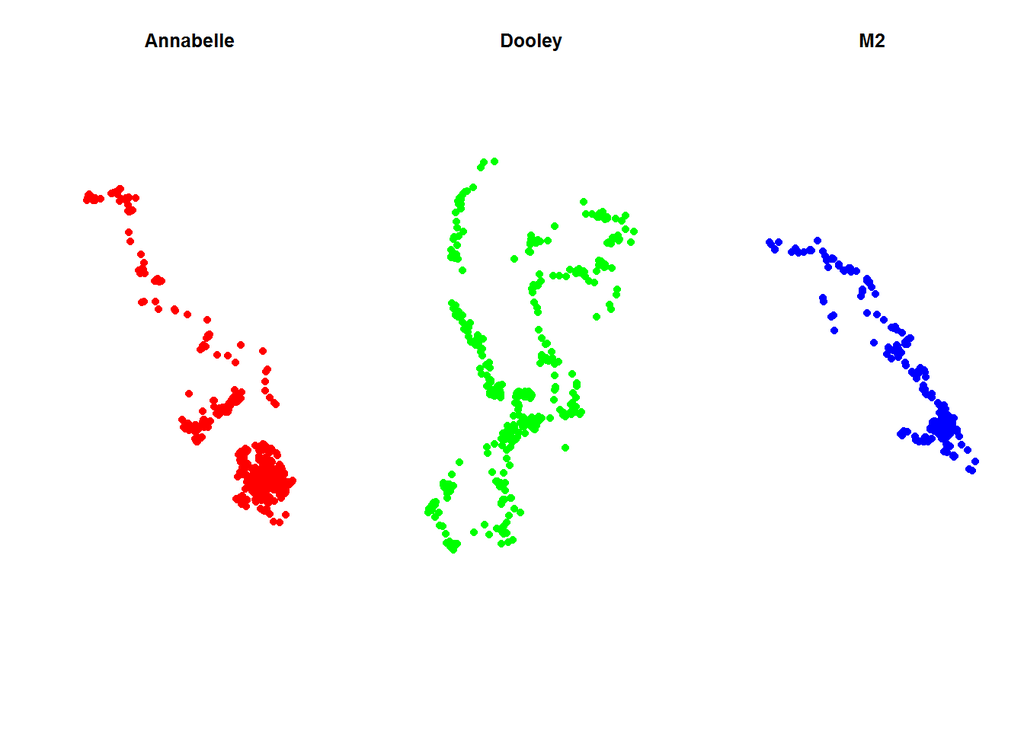

```r
# Now create a separate plot for each cassowary
par(mfrow=c(1,3))
plot(cassdat.sp[cassdat.sp$ANIMALID=="Annabelle",], col="red",pch=16,main="Annabelle")
plot(cassdat.sp[cassdat.sp$ANIMALID=="Dooley",], col="green",pch=16,main="Dooley")
plot(cassdat.sp[cassdat.sp$ANIMALID=="M2",], col="blue",pch=16,main="M2")
```

## 2.8 Coordinate Reference Systems (CRS)

Central to working with spatial data, is that these data have a coordinate reference system (CRS class) associated with it. Geographical CRS are expressed in degrees and associated with an ellipse, a prime meridian and a datum. Projected CRS are expressed in a measure of length and a chosen position on the earth, as well as the underlying ellipse, prime meridian and datum.

Most countries have multiple coordinate reference systems, and where they meet there is usually a big mess â this led to the collection by the European Petroleum Survey Group (EPSG) of a geodetic parameter dataset.

The EPSG list among other sources is used in the workhorse PROJ.4 library, and handles transformation of spatial positions between different CRS. This library is interfaced with R in the rgdal package, and the CRS class is defined partly in the sp package and partly in rgdal.

In the next step, we need to define the CRS which corresponds to our dataset. For the cassowary GPS dataset (`cassdat.sp`), we have not specified the CRS so the `@pro4string` slot is empty at the moment (`= NA`). We therefore need to refer to the correct proj4 string information which is contained within the rgdal package.

Our cassowary coordinates were collected in the **WGS 84** geographic datum in **Decimal Degrees**.

For simplicity, each projection can be referred to by a unique ID from the European Petroleum Survey Group (EPSG) geodetic parameter dataset. You can find the relevant EPSG code for your coordinate system from the website http://spatialreference.org. Here simply enter in a key word in the search box and select from the list the correct coordinate system. There is a map image in the top right of the site to help you.

The equivalent EPSG code for WGS 84 is [**4326**](http://spatialreference.org/ref/epsg/4326/)

to set the spatial projection we use the `proj4string()` function

```r
WGS <- CRS("+init=epsg:4326")
proj4string(cassdat.sp) <- WGS
```

In order to calculate distances and areas correctly, we need to now transform our data to the correct spatial projection.

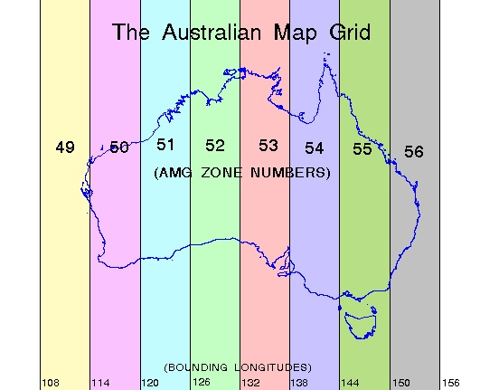

From the above graphic, can you see which is the correct projection for the Cairns area - here’s a [hint](http://spatialreference.org/ref/epsg/gda94-mga-zone-55/)

```r
GDA <- CRS("+init=epsg:28355") #The equivalent EPSG code for WGS 84 is 28355.
cassdat.P <- spTransform(cassdat.sp,GDA)
```

## 2.9 `SpatialPolygons` and home ranges

In the next section we will use functions contained in the [adehabitatHR](http://cran.r-project.org/web/packages/adehabitatHR/) R package to do some home range estimations.

Home range estimators are often used in animal movement studies to identify important areas to wildlife

More information on these estimators (plus the full citations) can be found in the [R package vignette for adehabitatHR](http://127.0.0.1:12661/help/library/adehabitatHR/doc/adehabitatHR.pdf)

The function for calculating the kernel density is `kernelUD()`. In this exercise, we will first estimate the kernel utilization distribution (KUD), and plot this distribution on a map

```r
# Generate our Home Ranges
kud <- kernelUD(cassdat.P[,1], h="href") ## Estimation of UD for the three animals
class(kud)
```

```
## [1] "estUDm"
```

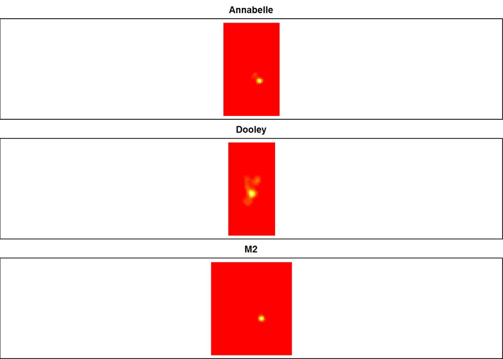

```r
image(kud) ## Plot the UD of the four animals
```

The objects produced when running the `kernelUD()` function are 3 x `estUD` objects (one for each animal). Collectively adehabitat has classifyed them as an `estUDm` object. This adehabitat’s own raster-style classification for a density surface.

Suppose instead of a continuous surface we wanted to extract the 95% and 50% home range contours from the probability surface? We can do this using the `getverticeshr()` function.

```r
# Extract the 95% and 50% kerneal for each animal

## 95% KUD
casskud.P95 <- getverticeshr(kud, percent = 95)
casskud.P95 ## Notice that this is now a SpatialPolygonsDataFrame object
```

```
## Object of class "SpatialPolygonsDataFrame" (package sp):
##
## Number of SpatialPolygons:  3
##
## Variables measured:
##                  id      area
## Annabelle Annabelle  515.4476
## Dooley       Dooley  266.2893
## M2               M2 4243.1291
```

```r
## 50% KUD
casskud.P50 <- getverticeshr(kud, percent = 50)
casskud.P50 ## Notice that this is now a SpatialPolygonsDataFrame object
```

```
## Object of class "SpatialPolygonsDataFrame" (package sp):
##
## Number of SpatialPolygons:  3
##
## Variables measured:
##                  id      area
## Annabelle Annabelle  56.59081
## Dooley       Dooley  62.76346
## M2               M2 311.19945
```

This generates a `SpatialPolygonDataframes` object, is a list of `Polygon` objects (such as animal home range contours) with CRS information and associated attribute data.

We can investigate the data contained within the object’s data frame using the `@data` command. We can also plot these polygons individually by specifying what line of our `SpatialPolygonsDateFrame` to plot.

```r
# Home range size
casskud.P95@data
```

```
##                  id      area
## Annabelle Annabelle  515.4476
## Dooley       Dooley  266.2893
## M2               M2 4243.1291
```

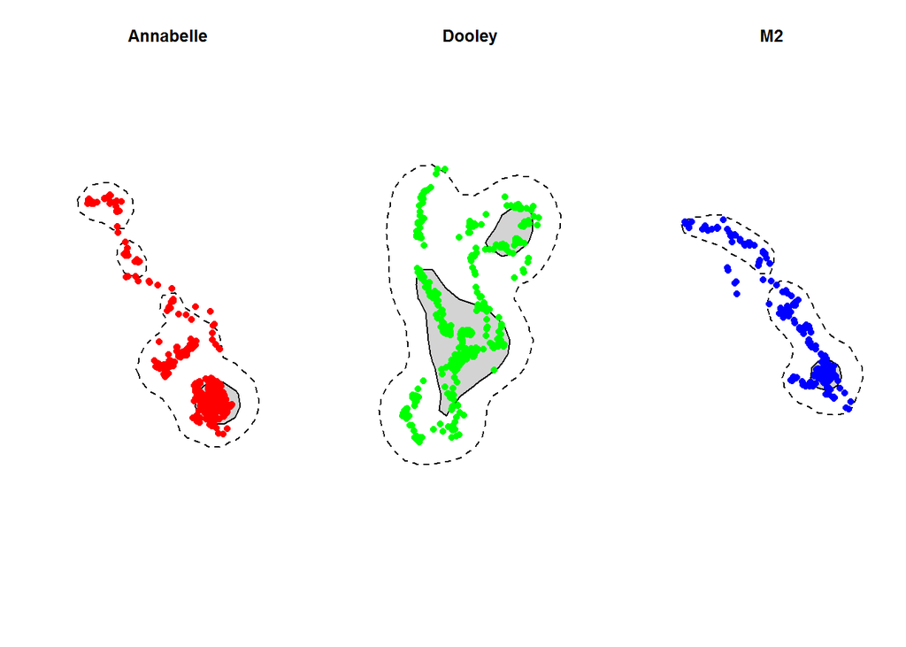

```r
# PLot the data for each animal as part of a 3 panel figure
par(mfrow=c(1,3))
plot(casskud.P95[1,],border=1,lty=2,main="Annabelle")
plot(casskud.P50[1,],col="lightgrey", add=T)
plot(cassdat.P[cassdat.P$ANIMALID=="Annabelle",], col="red",pch=16, add=T)

plot(casskud.P95[2,],border=1,lty=2,main="Dooley")
plot(casskud.P50[2,],col="lightgrey", add=T)
plot(cassdat.P[cassdat.P$ANIMALID=="Dooley",], col="green",pch=16,add=T)

plot(casskud.P95[3,],border=1,lty=2,main="M2")
plot(casskud.P50[3,],col="lightgrey", add=T)
plot(cassdat.P[cassdat.P$ANIMALID=="M2",], col="blue",pch=16,add=T)
```

## 2.10 `SpatialLines` and animal trajectories

In this exercise we are going to extract movement metrics from along an animal’s trajectory using the `as.ltraj` function in adehabitatLT.

### 2.10.1 Movement metrics

`ltraj` objects were specifically designed to store the movements of animals monitored using tracking devices.

On running this function, the following parameters are automatically produced…

1. `dx, dy, dt`: these parameters measured at relocation i describe the increments of the x and y directions and time difference between relocations i and i + 1.
2. `dist`: the distance between successive relocations
3. `abs.angle`: the absolute angle between the x direction and the step built by relocations i and i + 1.
4. `rel.angle`: the relative angle measures the change of direction between the step built by relocations i +ô 1 and i and the step built by relocations i and i + 1 (often called thwe “turning angle”).
5. `R2n`: the squared distance between the first relocation of the trajectory and the current relocation

```r
# Extract the date field, the animal id field and the coordinates of each relocation and save as a vector
GPSdates <- as.POSIXct(cassdat.P@data$DATE)
GPSids <- cassdat.P@data$ANIMALID
GPSxys <- coordinates(cassdat.P)

# Convert to an ltraj object
cassdat.lt <- as.ltraj(xy=GPSxys,date=GPSdates,id=GPSids,proj4string = GDA) # Assign it the correct coordinate reference system

#Have a look at the newly created ltraj object
cassdat.lt
```

```
##
## *********** List of class ltraj ***********
##
## Type of the traject: Type II (time recorded)
## * Time zone unspecified: dates printed in user time zone *
## Irregular traject. Variable time lag between two locs
##
## Characteristics of the bursts:
##          id     burst nb.reloc NAs          date.begin            date.end
## 1 Annabelle Annabelle     1005   0 2011-04-19 07:30:40 2011-09-24 23:00:21
## 2    Dooley    Dooley      636   0 2011-05-26 00:00:19 2011-06-22 07:30:38
## 3        M2        M2      729   0 2011-05-19 00:31:01 2011-09-13 01:31:02
##
##
##  infolocs provided. The following variables are available:
## [1] "pkey"
```

```r
head(cassdat.lt[[1]])
```

```
##            x       y                date        dx         dy     dist
## 737 331703.9 8231451 2011-04-19 07:30:40 -10.88555  24.040726 26.39037
## 738 331693.0 8231475 2011-04-19 08:30:32  37.16244 -16.870645 40.81257
## 739 331730.1 8231458 2011-04-19 10:00:38 -40.50876   6.443644 41.01804
## 740 331689.6 8231465 2011-04-19 10:30:35 -13.34181 -33.297807 35.87127
## 741 331676.3 8231431 2011-04-19 17:30:54  24.27784  87.491437 90.79739
## 742 331700.6 8231519 2011-04-19 18:30:29  24.48019 -24.159227 34.39401
##        dt       R2n  abs.angle rel.angle
## 737  3592    0.0000  1.9959733        NA
## 738  5406  696.4518 -0.4261507 -2.422124
## 739  1797  741.8849  2.9838463 -2.873188
## 740 25219  387.8796 -1.9518900  1.347449
## 741  3575 1147.7712  1.3001183 -3.031177
## 742  1802 4608.6999 -0.7787995 -2.078918
```

You’ll see that the function `as.ltraj` has automatically computed the descriptive parameters from the x and y coordinates, and from the date. Note that `dx,dy,dist` are expressed in the units of the coordinates x,y (here, *metres*), the duration between relocations is in *seconds* and abs.angle,rel.angle are expressed in *radians*.

A graphical display of the bursts can be obtained simply by:

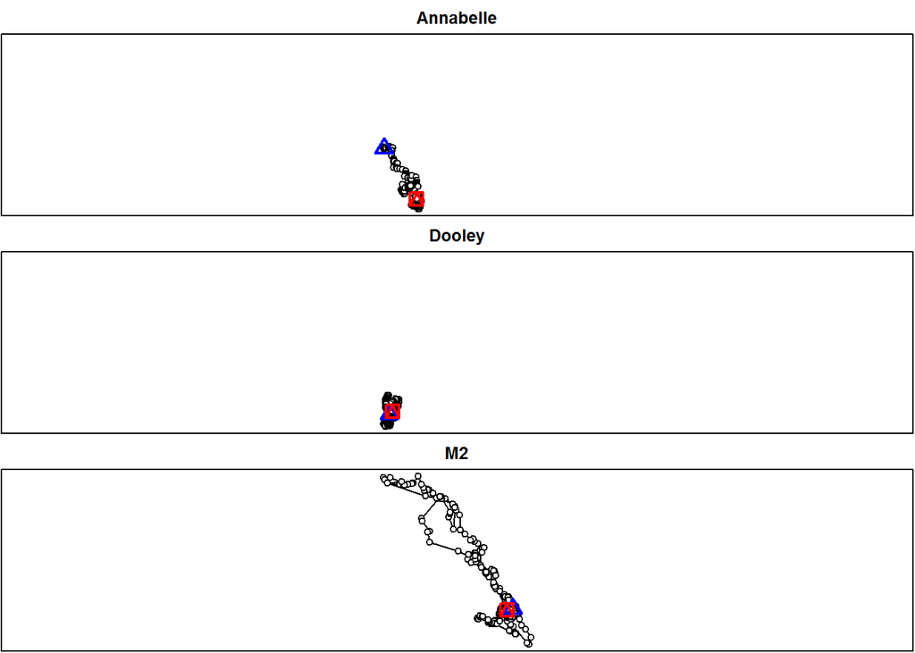

```r
plot(cassdat.lt)
```

### 2.10.2 `SpatialLines` objects

Next we will extract what is the minimum distance each cassowary travelled during the survey period.

To do this we are going to convert our data to a `SpatialLinesDataFrame`. `Line` objects are basically a collection of 2D coordinates linked together in a specific order by a series of lines. `Lines` objects are a list of Line objects, such as the contours on a single elevation, and each hold a specific ID (i.e. the depth of that particular contour). `SpatialLines` are formed by attributing the Lines object with spatial information related to the coordinate reference system. A `SpatialLinesDataFrame` is a spatial lines object with attribute data (e.g. animal id, distance travelled etc.)

The `ltraj2sldf` functions convert the class `ltraj` available in adehabitatLT towards classes available in the package sp.

```r
# Convert the ltraj object into a spatial lines dataframe
casstrak.P <- ltraj2sldf(cassdat.lt,byid=TRUE)

# Assign it the correct coordinate reference system
proj4string(casstrak.P) <- GDA

class(casstrak.P)
```

```
## [1] "SpatialLinesDataFrame"
## attr(,"package")
## [1] "sp"
```

### 2.10.3 Distance travelled

`SpatialLines` and `SpatialLinesDataframes` can be very useful if you want to calculate the distance covered or the circumference of an area.

Here we use the `SpatialLinesLengths()` function to calculate the minimum distance moved by each individual cassowary in meters

```r
# Extract the lengths of these lines in meters
# 1: Annabelle; 2: Dooley; 3: M2
casstrak.P@data$Distance <- SpatialLinesLengths(casstrak.P)

casstrak.P@data
```

```
##                  id  Distance
## Annabelle Annabelle  45594.80
## Dooley       Dooley  19819.68
## M2               M2 153587.13
```

## 2.11 Writing a shapefile object from **R**

Once you have the `Spatial` object the way you like it, you will want to export it to view in a GIS. Here we show you two options for exporting your `Spatial` object, as a **shapefile** or as a **.kml** for viewing in [Google Earth](https://www.google.com/earth/). As with reading in spatial objects, there are a number of **R** packages out there to help you. Simply type `??kml` or `??shapefile` to look up a few of these options.

In this example we are goint to use the `writeOGR()` function in the rgdal package. to write the data containing the movement metrics to a shapefile.

The `ld` function allows to quickly convert an object of class ltraj to a data.frame. We then reproject our data back to Longs and Lats (WGS 1984) for viewing in Arc GIS or Google Earth

```r
# Convert the ltraj object into a standard data frame
cassdat.lt.proj <- ld(cassdat.lt) # Change to a dataframe object
cassdat.lt.proj$date <- as.POSIXct(cassdat.lt.proj$date) # Reassigns date as a date object

# Convert the data frame object into a SpatialPointsDataFrame
coordinates(cassdat.lt.proj) <- ~x+y # Extract the coordinates
proj4string(cassdat.lt.proj) <- GDA  # Assigns the coordinate reference system

# Change it back to WGS 1984 projection
cassdat.lt.WGS <- spTransform(cassdat.lt.proj,WGS)
```

Finally we run the `writeOGR` function to write this file to disk. We specify the folder as being within the GIS folder.

```r
writeOGR(cassdat.lt.WGS, # This field needs to be a SpatialPoints*, SpatialLines* or SpatialPolygons* object
         dsn="GIS",
         layer= "cass_points", driver="ESRI Shapefile",
         dataset_options=c("NameField=id"))
```

*Extra task* - try writing the `SpatialPolygons` object containing our home ranges and our `SpatialLines` object containing our trajectory lines to file.

## 2.12 Visualising your data in [Google Earth](https://www.google.com/earth/)

### 2.12.1 Visualising points

Google Earth offers a highly flexible way of visualising your spatial data. `writeOGR()` in the rgdal library also offers this functionality. However the data **MUST** be geographical coordinates with datum WGS84.

If our data isn’t already in the datum WGS84, We can transform it using the `spTransform()` function.

The [plotKML](http://plotkml.r-forge.r-project.org/) R package also offers some more advanced functionality for visualising your data in [Google Earth](https://www.google.com/earth/)). The file will be written in your project folder.

```r
## First lets export the cassowary locations (Points) (already in WGS84)
writeOGR(cassdat.lt.WGS,
         dsn="GIS/cass_points.kml",
         layer= "gps", driver="KML",
         dataset_options=c("NameField=id"))
```

If you have time, try exporting your lines and polygons objects as .kml file. You will find help on how to do this by typing `?kml` or having a look on [Google](http://google.com)

### 2.12.2 Visualising animations

Next convert your data into a STIDF object to create an animation of your Track

```r
# create a STIDF object:
library(spacetime)
library(plotKML)
newXY <- SpatialPoints(coordinates(cassdat.lt.WGS))
proj4string(newXY) <- CRS("+proj=longlat +datum=WGS84")
newXY.st <- STIDF(newXY, time = cassdat.lt.WGS@data$date, data = data.frame(id=cassdat.lt.WGS@data[,c("id")]))

# write to a KML file:
shape <- "http://maps.google.com/mapfiles/kml/pal2/icon18.png"
kml(newXY.st, dtime = 24*3600, colour = id, shape = shape, labels = "", kmz=TRUE)
```

***End of Session 1

——————————————

# 3 Session 2: tidy style, pipes and ggplot2

[figure not shown]

The tidyverse

In this session we will be having a look into the *tidyverse* group of R packages which have really revolutionised the way we work with big data and the way we visualise our results.

## 3.1 The tidyverse

### 3.1.1 What is the tidyverse?

- The [tidyverse](http://tidyverse.org/) is the collective name given to suite of R packages designed mostly by Hadley Wickham.
- Before it was formalised in 2016 it was loosely referred to as the `hadleyverse`.
- Packages share a common API and design philosophy intended to create a **“Pit of Success”**.

### 3.1.2 Members of the tidyverse

broom, **dplyr**, forcats, **ggplot2**, haven, httr, hms, jsonlite, lubridate, magrittr, modelr, purrr, **readr**, readxl, stringr, tibble, rvest, **tidyr**, xml2

### 3.1.3 tidy style

**tidyverse** code has a certain look:

```r
exampledata %>%
  gather(code, value, new_sp_m014:newrel_f65, na.rm = TRUE) %>%
  mutate(code = stringr::str_replace(code, "newrel", "new_rel")) %>%
  separate(code, c("new", "var", "sexage")) %>%
  select(-new, -iso2, -iso3) %>%
  separate(sexage, c("sex", "age"), sep = 1)
```

**ggplot2**, one of the packages in the tidyverse, has a similar look…

```r
exampledata  %>%
ggplot(aes(x=ntags, y=nPU)) +
  geom_point(alpha = 0.1,show_guide = F) +
  geom_jitter(width = 0.01, height = 0.01) +
  xlab("Number of tags") +
  ylab("Number of planning units") +
  theme_bw() +
  theme(legend.title=element_blank(),
        axis.line = element_line(colour = "black"),
        panel.grid.major = element_blank(),
        panel.grid.minor = element_blank(),
        panel.border = element_blank(),
        panel.background = element_blank()) +
  guides(color=guide_legend("season"), fill = guide_legend("season")) +
  geom_smooth(method="lm", formula = y~log(x), se = F, size = 1)
```

-[Grolemund, Wickham, 2016 R for Data Science](http://r4ds.had.co.nz/tidy-data.html#case-study) * The documentation of this style is still evolving. * [This is a good start](https://rpubs.com/yeedle/tidyguide)

## 3.2 Loading in our spatial data

First lets load the dataset we created in Session 1.

It is extremely easy to import spatial data into R. We will use the `readOGR` function from the rgdal package. This function is an interface to the OGR software, a famous GIS library used to import many different vector formats.

```r
library(rgdal)
cassdat.lt.WGS <- readOGR("GIS", "cass_points")
#check our data has loaded
head(cassdat.lt.WGS)
```

```
##           coordinates                date        dx         dy     dist
## 1 (145.427, -15.9908) 2011-04-19 07:30:40 -10.88555  24.040726 26.39037
## 2 (145.427, -15.9905) 2011-04-19 08:30:32  37.16244 -16.870645 40.81257
## 3 (145.428, -15.9907) 2011-04-19 10:00:38 -40.50876   6.443644 41.01804
## 4 (145.427, -15.9906) 2011-04-19 10:30:35 -13.34181 -33.297807 35.87127
## 5 (145.427, -15.9909) 2011-04-19 17:30:54  24.27784  87.491437 90.79739
## 6 (145.427, -15.9901) 2011-04-19 18:30:29  24.48019 -24.159227 34.39401
##      dt       R2n  abs_angle rel_angle        id     burst
## 1  3592    0.0000  1.9959733        NA Annabelle Annabelle
## 2  5406  696.4518 -0.4261507 -2.422124 Annabelle Annabelle
## 3  1797  741.8849  2.9838463 -2.873188 Annabelle Annabelle
## 4 25219  387.8796 -1.9518900  1.347449 Annabelle Annabelle
## 5  3575 1147.7712  1.3001183 -3.031177 Annabelle Annabelle
## 6  1802 4608.6999 -0.7787995 -2.078918 Annabelle Annabelle
##                            pkey
## 1 Annabelle.2011-04-19 07:30:40
## 2 Annabelle.2011-04-19 08:30:32
## 3 Annabelle.2011-04-19 10:00:38
## 4 Annabelle.2011-04-19 10:30:35
## 5 Annabelle.2011-04-19 17:30:54
## 6 Annabelle.2011-04-19 18:30:29
## Coordinate Reference System (CRS) arguments: +proj=longlat
## +datum=WGS84 +no_defs +ellps=WGS84 +towgs84=0,0,0
```

## 3.3 Introduction to pipes `%>%`

[figure not shown]

pipes are awesome!

Now that we’ve successfully loaded in our spatial dataset, lets start having a closer look at the data using pipes `%>%`

- Originally from the `magrittr` package but has been imported to the `tidyverse`.
- `%>%` is an **infix operator**. This means it takes two operands, left and right.
- ‘Pipes’ the **output** of the last expression/function (left) forward to the **first input** of the next funciton (right).

```r
#For example, to see what class our data is in, we could use this code...
class(cassdat.lt.WGS)

#Alternatively in the tidy verse we could use this code...
cassdat.lt.WGS %>% class()
```

### 3.3.1 Benefits of %>% and tidy style

- Functions flow in natural order that tells story about data.
- Code effects are easy to reason about by inserting `View()` or `head()` into pipe chain.
- Common style makes it easy to understand collaborator (or your own) code.

```r
# First convert the spatial dataframe back to a data frame
cassdat.df <- as.data.frame(cassdat.lt.WGS)
cassdat.df$date <- as.POSIXct(cassdat.df$date)

# Now insert functions into the pipe chain
#cassdat.df %>% View()
cassdat.df %>% head()
```

```
##                  date        dx         dy     dist    dt       R2n
## 1 2011-04-19 07:30:40 -10.88555  24.040726 26.39037  3592    0.0000
## 2 2011-04-19 08:30:32  37.16244 -16.870645 40.81257  5406  696.4518
## 3 2011-04-19 10:00:38 -40.50876   6.443644 41.01804  1797  741.8849
## 4 2011-04-19 10:30:35 -13.34181 -33.297807 35.87127 25219  387.8796
## 5 2011-04-19 17:30:54  24.27784  87.491437 90.79739  3575 1147.7712
## 6 2011-04-19 18:30:29  24.48019 -24.159227 34.39401  1802 4608.6999
##    abs_angle rel_angle        id     burst                          pkey
## 1  1.9959733        NA Annabelle Annabelle Annabelle.2011-04-19 07:30:40
## 2 -0.4261507 -2.422124 Annabelle Annabelle Annabelle.2011-04-19 08:30:32
## 3  2.9838463 -2.873188 Annabelle Annabelle Annabelle.2011-04-19 10:00:38
## 4 -1.9518900  1.347449 Annabelle Annabelle Annabelle.2011-04-19 10:30:35
## 5  1.3001183 -3.031177 Annabelle Annabelle Annabelle.2011-04-19 17:30:54
## 6 -0.7787995 -2.078918 Annabelle Annabelle Annabelle.2011-04-19 18:30:29
##   coords.x1 coords.x2
## 1  145.4273 -15.99075
## 2  145.4272 -15.99053
## 3  145.4275 -15.99069
## 4  145.4271 -15.99063
## 5  145.4270 -15.99093
## 6  145.4272 -15.99014
```

## 3.4 Dplyr

- `dplyr` is the data wrangling workhorse of the tidyverse.
- Provides functions, **verbs**, that can manipulate tibbles into the shape you need for analysis.
- Has many backends allowing dplyr code to work on data stored in SQL databases and big data clusters.
  - Works via translation to SQL. Keep an eye out for the SQL flavour in `dplyr`

### 3.4.1 Basic vocabulary

- `select()` columns from a tibble
- `filter()` to rows matching a certain condition
- `mutate()` a tibble by changing or adding rows
- `arrange()` rows in order
- `group_by()` a variable
- `summarise()` data over a group using a function

Check out this useful [Cheatsheet](https://www.rstudio.com/wp-content/uploads/2015/02/data-wrangling-cheatsheet.pdf) for data wrangling.

### 3.4.2 `select`

We can use the `select` function in Dplyr to choose the columns we want to include for our analyses and plotting

```r
# Select the rows we are interested in
cassdat.df2 <-
  cassdat.df %>%
  select(coords.x1,coords.x2,id,date,dt,dist,abs_angle,rel_angle,R2n) %>%
  select(-R2n)

head(cassdat.df2)
```

```
##   coords.x1 coords.x2        id                date    dt     dist
## 1  145.4273 -15.99075 Annabelle 2011-04-19 07:30:40  3592 26.39037
## 2  145.4272 -15.99053 Annabelle 2011-04-19 08:30:32  5406 40.81257
## 3  145.4275 -15.99069 Annabelle 2011-04-19 10:00:38  1797 41.01804
## 4  145.4271 -15.99063 Annabelle 2011-04-19 10:30:35 25219 35.87127
## 5  145.4270 -15.99093 Annabelle 2011-04-19 17:30:54  3575 90.79739
## 6  145.4272 -15.99014 Annabelle 2011-04-19 18:30:29  1802 34.39401
##    abs_angle rel_angle
## 1  1.9959733        NA
## 2 -0.4261507 -2.422124
## 3  2.9838463 -2.873188
## 4 -1.9518900  1.347449
## 5  1.3001183 -3.031177
## 6 -0.7787995 -2.078918
```

### 3.4.3 `filter` and `arrange`

Subset the data to rows matching logical conditions and then arrange according to particular attributes

```r
filter(cassdat.df2, id == "M2") %>%
  arrange(dist)

filter(cassdat.df2, id == "M2") %>%
  arrange(desc(dist))
```

### 3.4.4 `mutate`

Add additional variables to an existing data frame

```r
# Add an hour onto the time fields
cassdat.df3 <-
  cassdat.df2 %>%
  mutate(date2 = date + (60*60*10)) # Adds a date field and then changes the data from UTM to AEST)(i.e. adds 10 hrs)

# Here we use functions contained inthe lubridate package to add date columns to our dataset
library(lubridate)
# extract hour and month using lubridate function
# attach the column using the mutate function
cassdat.df4 <-
  cassdat.df3 %>%
  mutate(hourofday = hour(date2)) %>%
  mutate(month = month(date2))

## Now convert the duration between locations from seconds to minutes
cassdat.df5 <-  cassdat.df4 %>%
  mutate(dt_hr= (dt)/(60*60))
```

### 3.4.5 `summarise`

Determine the total distances travelled for the total duration plus in a given month

```r
cassdat.df5 %>%
  group_by(id) %>%
  summarise(totaldist = sum(dist, na.rm=T))
```

```
## # A tibble: 3 × 2
##          id totaldist
##      <fctr>     <dbl>
## 1 Annabelle  45594.80
## 2    Dooley  19819.68
## 3        M2 153587.13
```

```r
cassdat.df5 %>%
  group_by(month, id) %>%
  summarise(monthlydist = sum(dist, na.rm=T))
```

```
## Source: local data frame [13 x 3]
## Groups: month [?]
##
##    month        id monthlydist
##    <dbl>    <fctr>       <dbl>
## 1      4 Annabelle    7958.498
## 2      5 Annabelle   10227.960
## 3      5    Dooley    2483.462
## 4      5        M2    1538.413
## 5      6 Annabelle    2627.537
## 6      6    Dooley   17336.217
## 7      6        M2   42398.049
## 8      7 Annabelle    7254.834
## 9      7        M2   47762.055
## 10     8 Annabelle    7368.010
## 11     8        M2   36127.211
## 12     9 Annabelle   10157.963
## 13     9        M2   25761.405
```

## 3.5 Data visualisation using `ggplot`

ggplot2 is a powerful data visualization package for the R programming language. The system provides **mappings** from your data to **aesthetics** which are used to construct beautiful plots.

The package makes it very easy to generate some very impressive figures and utilise a range of colour palettes. In fact it is so easy to use, most struggles with ggplot2 are really struggles with data!

Documentation for ggplot can be found [here](http://ggplot2.org/) and [here](http://docs.ggplot2.org/current/index.html).

There is also this awesome [Cheatsheet](https://www.rstudio.com/wp-content/uploads/2015/03/ggplot2-cheatsheet.pdf) for ggplot2

In the below script we call the data set we have just made (`cassdat.df5`) and then pipe it into the ggplot function. We than tell ggplot that we want to plot a box plot

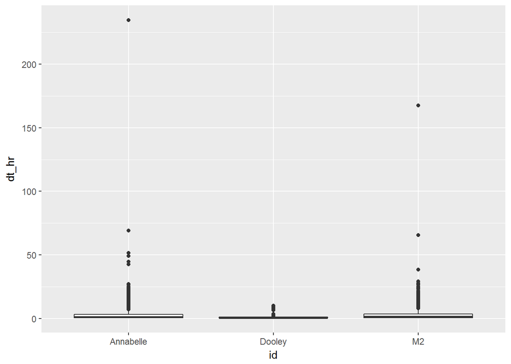

```r
library(ggplot2)

cassdat.df5 %>%
  ggplot(mapping = aes(x = id, y = dt_hr)) +
  geom_boxplot()
```

In this case, we cant really see what’s on the y axis as there’s so many outliers. Lets put a log scale on the y axis to see it better and change the name of this axis to reflect our change

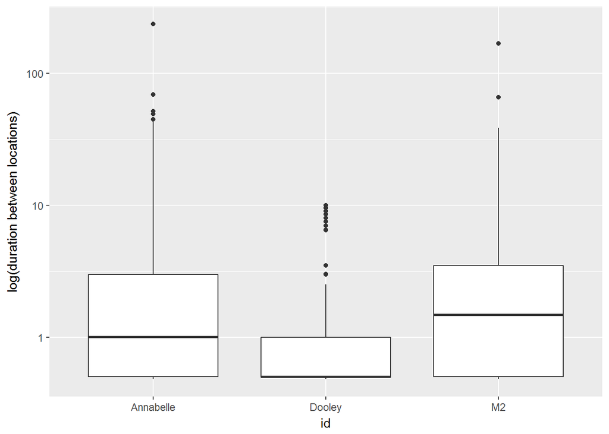

```r
cassdat.df5 %>%
  ggplot(mapping = aes(x = id, y = dt_hr)) +
  geom_boxplot() +
  scale_y_log10() +
  ylab("log(duration between locations)")
```

We can also use the `facet_wrap` function to generate a separate plot for each monthly category

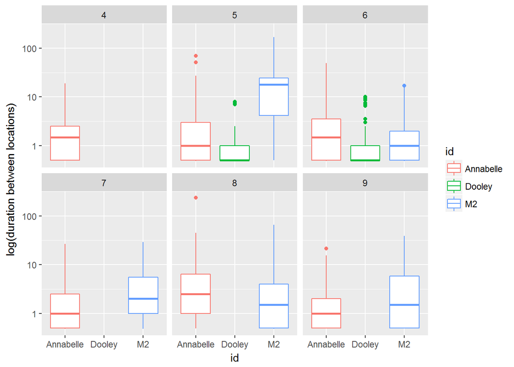

```r
cassdat.df5 %>%
  ggplot(mapping = aes(x = id, y = dt_hr, colour=id)) +
  geom_boxplot() +
  scale_y_log10() +
  ylab("log(duration between locations)") +
  facet_wrap(~month)
```

Next we generate a circular plot to see when the locations for each bird were obtained

```r
library(circular)
```

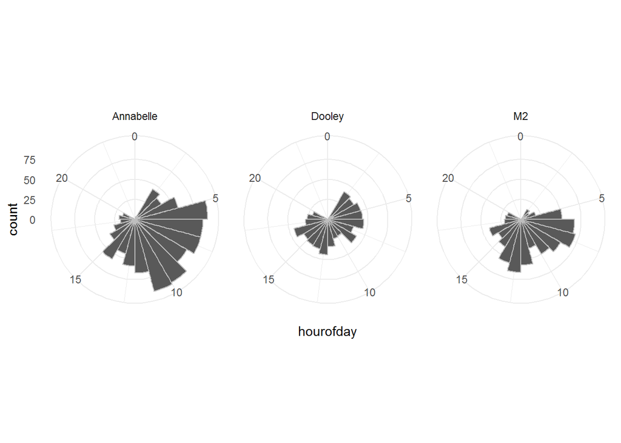

```r
cassdat.df5 %>%
ggplot(mapping = aes(x =  hourofday)) +
  geom_histogram(breaks = seq(0, 24, by=1), colour = "grey") +
  coord_polar(start = 0) +
  facet_wrap(~id) +
  theme_minimal()
```

Notice that the devices were programmed as to not obtain location data at night (i.e. when the birds were likely roosting). Notice how we used `theme_minimal()` to generate a simple plot without and extra colouring in the figure.

In the next exercise we’ll generate a circular plot showing the direction traveled by our tagged birds

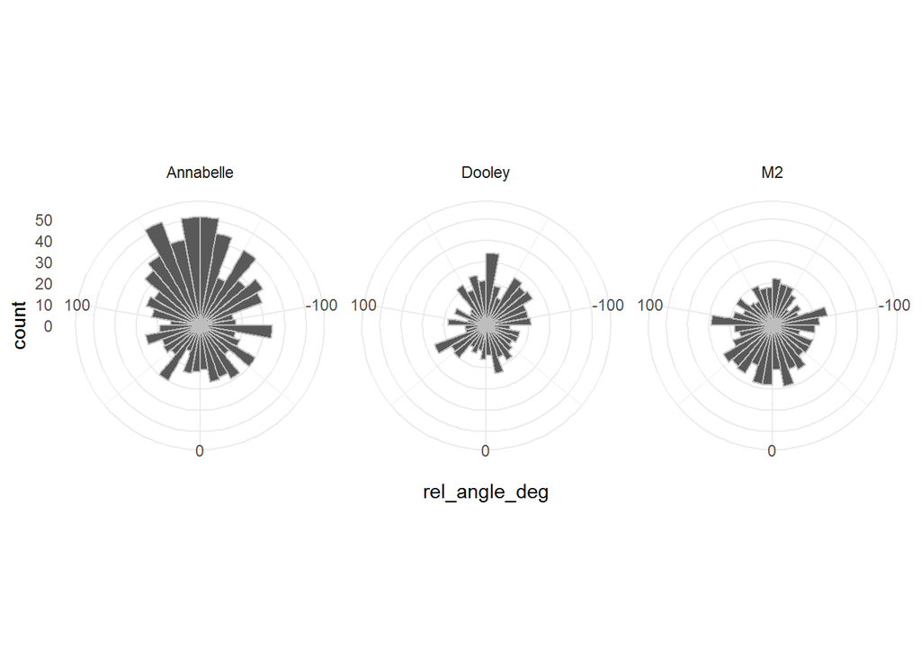

```r
rad2deg <- function(rad) {(rad * 180) / (pi)}

cassdat.df6 <-
  cassdat.df5 %>%
  mutate(abs_angle_deg = rad2deg(abs_angle)) %>%
  mutate(rel_angle_deg = rad2deg(rel_angle))

cassdat.df6 %>%
  ggplot(mapping = aes(x =  rel_angle_deg)) +
  geom_histogram(breaks = seq(-180, 180, by = 10), colour = "grey") +
  coord_polar(start = 0) + theme_minimal()+
  facet_wrap(~id) +
  theme_minimal()
```

## 3.6 Interactive maps using leaflet

For our last task I want to show you how you can make some really cutting edge visuals with R, which will help you share your work with collaborators. We are going to make a simple web-based map using the leaflet package. The leaflet package utilises the open-access leaflet JavaScript library (a web programming language), to create web-based maps. We will cover a basic map with some points on it today. See [Rstudio’s leaflet page](http://rstudio.github.io/leaflet/) for help and more mapping features, like polygons.

To get started with leaflet, first, make sure you have the leaflet and htmlwidgets packages installed, and then load it into this session:

```r
library(leaflet)
library(htmlwidgets)
```

Next we’ll add a new column to our data specifying the colour we want our points to be, before transforming our data to a `SpatialPointsDataframe` object.

```r
## Import cleansed 2014 tagged animal file from ZoaTrack

cassdat.df7 <- cassdat.df6 %>%
  mutate(ANIMALCOL = ifelse(id=="Annabelle","red",
                            ifelse(id=="Dooley","green",
                                   "blue")))

coordinates(cassdat.df7) <- ~coords.x1 + coords.x2
```

We start by specifying a base layer, then we can add features to it. We will string together our layers using the pipes `(%>%)` command.

The below code first creates a map widget using the cassowary data frame. Then we `addTiles`, which is the background to the map. See [this page](http://rstudio.github.io/leaflet/basemaps.html) for the numerous base map options. Finally, we add some markers, located using the longitude and latitude variables in the cassowary data frame:

```r
mymap <-
leaflet(cassdat.df7) %>%

  #Base maps
  addTiles(group = "OSM (default)") %>%  # Add default OpenStreetMap map tiles
  addProviderTiles("Esri.WorldImagery") %>%

  #Overlay points
  addCircleMarkers(popup=paste0('id = ', cassdat.df7@data$id, ", DATE = ", cassdat.df7@data$date),
                   weight=2,
                   radius=5,
                   color = cassdat.df7@data$ANIMALCOL,
                   stroke = FALSE, fillOpacity = 0.4, group = "Points") %>%

  #Add Layers control
  addLayersControl(
    baseGroups = c("OSM (default)","Esri.WorldImagery"),
    overlayGroups = c("Points"),
    options = layersControlOptions(collapsed = FALSE)) %>%

  #Add a Legend
  addLegend("topright",
            colors=c("red","green","blue"),
            labels=c("Annabelle", "Dooley","M2"),
            labFormat = labelFormat(prefix = "$"),
            opacity = 1)

mymap
```

Finally you can save this leaflet document at a .html file and share it with your friends or colleagues…

```r
saveWidget(mymap, file="mymap.html") # uses the htmldidgets package

# Notice the file is saved to your working directory
```

*Extra task* - try writing the `SpatialPolygons` object containing our home ranges and our `SpatialLines` object containing our trajectory lines to this leaflet object

***End of Session 2